# Accounting, Analysis and Governance in Complex Deals

Arndt Weinrich

weinrich@rsm.nl

Rotterdam School of Management

# Valuation and Pricing

> **BMME303**

> Accounting, Analysis and Governance in Complex Deals

## Value and Price

### Setting the Stage

#### Value and Price Refer to Different Things

[figure not shown]

| Price | Value |
| --- | --- |
| Observable/Unique | Can be Ambiguous |
| No Model | Model/Theory Needed |

*We will ignore this distinction and use the terms interchangeably*

# Measuring Value

## Measuring Value

### Valuation and Pricing

> **Under (restrictive) assumptions, multiple valuation methods collapse to the same result.**

*Let’s explore when discount valuation approaches and and ratio/multiple approaches can be seen as two sides of the same coin.*

## From Fundamental to Market-Based Valuation

### Valuation and Pricing

#### Dividend Discount Model (DDM) w/o Growth

Assume that all earnings are paid out as dividends:

$$\boxed{P_0 = \frac{D_1}{r - g}} = \frac{E_1}{r} \Rightarrow P_0 = \frac{E_1}{r}$$

with $D=E$ and $g=0$, where

- $D_1$: Dividend next year, which equals earnings per share $E_1$
- $r$: Cost of Equity (required return)
- $P_0$: Current stock price, which can be expressed as $\frac{E_1}{r}$ under DDM w/o growth

*DDM is one of the most fundamental approaches to valuation. It states that the value of a stock today equals the present value of all future dividends. (Session 1 BM04AFM!)*

## From Fundamental to Market-Based Valuation

### Valuation and Pricing

#### P/E Ratio

Rearrange $P_0 = \frac{E_1}{r}$ from DDM w/o growth to derive at a forward looking P/E ratio:

$$\frac{P_0}{E_1} = \frac{E_1/r}{E_1} \Rightarrow \boxed{\text{P/E} = \frac{1}{r}}$$

**$\Rightarrow$ The forward-looking P/E ratio is the ratio of the current share price to next year’s earnings**

## From Fundamental to Market-Based Valuation

### Valuation and Pricing

#### P/E Ratio

P/E ratio determines a common **Multiples Approach** to valuation:
$$P_0 = E_1 \times \text{(Average of comparable firms' PE ratios)}$$

**$\Rightarrow$ Multiples are fundamentally connected to discount models!**

- Incorporate the same fundamental valuation principles as more complex discount valuation approaches, but with greater simplicity.
- Selecting truly comparable firms is critical for the validity of the multiples approach!

## From Fundamental to Market-Based Valuation

### Valuation and Pricing

#### Equivalence of P/E and DDM

*Multiples Approach*

$$P_0 = E_1 \times \text{(Average of comparable firms' PE ratios)}$$

*DDM w/o Growth*

$$P_0 = E_1 \times \frac{1}{r}$$

**$\Rightarrow$ Both approaches yield the same valuation when the average P/E of comparable firms appropriately reflects required return (and growth) of the focal firm.**

## From Fundamental to Market-Based Valuation

### Valuation and Pricing

#### Market-to-Book Ratio M/B

Derive at another direct approach to equity valuation:

- Define $B$ as the Book value of Equity, then $ROE_1 = \frac{E_1}{B_0} \Rightarrow E_1 = ROE_1 \times B_0$
- $P_0 = \frac{E_1}{r} = \frac{ROE_1 \times B_0}{r}$

$$\text{M/B} = \frac{P_0}{B_0} = \frac{ROE_1 \times B_0 / r}{B_0} \Rightarrow \boxed{\text{M/B} = \frac{ROE}{r}}$$

**$\Rightarrow$ M/B incorporate profitability beyond just the required return (P/E)**

## From Fundamental to Market-Based Valuation

### Valuation and Pricing

#### Reconciliation between P/E and M/B

- $\text{P/E} = \frac{1}{r}$
- $\text{M/B} = \frac{ROE}{r} = ROE \times\text{P/E}$

$$\boxed{\text{M/B} = ROE \times\text{P/E}}$$

## From Fundamental to Market-Based Valuation

### Valuation and Pricing

#### Early Conclusions (No Growth Case)

- P/E ratio is entirely driven by the required return r, nothing else.
- M/B ratio is driven by both profitability (ROE) and the required return r.
- ROE vs. r is the key comparison for value creation:
  - If ROE > r $\Rightarrow$ M/B > 1 (firm creates value)
  - If ROE = r $\Rightarrow$ M/B = 1
  - If ROE < r $\Rightarrow$ M/B < 1 (firm destroys value)

## From Fundamental to Market-Based Valuation

### Valuation and Pricing

#### What happens if we introduce growth?

|  | **w/o Growth** | **w Growth** | **Note** |
| --- | --- | --- | --- |
| P/E | $\frac{1}{r}$ | $\frac{1 - b}{r - ROE \times b}$ | P/E increases only if growth is value-creating (ROE > r) |
| M/B | $\frac{ROE}{r}$ | $\frac{ROE \times (1 - b)}{r - ROE \times b}$ | M/B is sensitive to both payout and profitability |

**$\Rightarrow$ Growth introduces important tradeoffs between payout, reinvestment rate, and return on equity**

*The growth rate $g$ is defined as the product of the retention ratio $b = \frac{E - D}{E}$ and the return on equity (ROE). This means that the growth rate is directly influenced by how much of the earnings are retained for reinvestment in the firm and how effectively those retained earnings generate returns.*

## Early Takeaways

### From Fundamental to Market-Based Valuation

#### Discount Rate $r$

- A **higher $r$** decreases both **P/E** and **M/B**
- Opportunity cost of capital for investors

#### Profitability: ROE

- If $ROE > r$: the firm creates value $\Rightarrow$ M/B > 1.
- If $ROE < r$: the firm destroys value $\Rightarrow$ M/B < 1.
- Also indirectly boosts P/E when retained earnings fuel value-creating growth.

#### Growth Rate $g$

- **P/E** and **M/B** both **increase** if retained earnings (via $b > 0$) fund profitable growth:
  - Only if **ROE > r**
  - Otherwise, growth **reduces value** (you reinvest at a rate lower than investor return expectations)

#### Payout Policy (Payout Rate = 1 – b)

- **Lower payouts** $\Rightarrow$ more retained earnings ⇒ higher growth (if ROE > r)
- **Higher payouts** $\Rightarrow$ less growth but more cash returned to shareholders

## From Fundamental to Market-Based Valuation

### Valuation and Pricing

#### What happens if we want to value equity and debt?

| **Equity-side** |  | **Enterprise-side** |
| --- | --- | --- |
| Cost of Equity |  | WACC (Weighted Average Cost of Capital) |
| ROE |  | ROIC (Return on Invested Capital) |
| **P/E** |  | EV/EBIT or **EV/EBIT(D)A** |
| M/B |  | EV / IC (Invested Capital) |

- Equity value = Value of shareholders’ stake in the business
- Enterprise value = Value of the whole business, sum of the market values of the various claims on the business

# Multiples in Action

## Segway through the Valuation Jungle

### DePamphilis (2025) *Relative, Asset-Oriented, and Real Option Valuation Basics*

#### Selected Valuation Approaches

- Comparable firms, transactions […]
- Enterprise value (EV) to EBITDA
- Price / Earnings to Growth ratio (PEG)
- Value-Driver-Based Valuation
- […]

## Segway through the Valuation Jungle

### Valuation and Pricing

#### Valuation Numerator

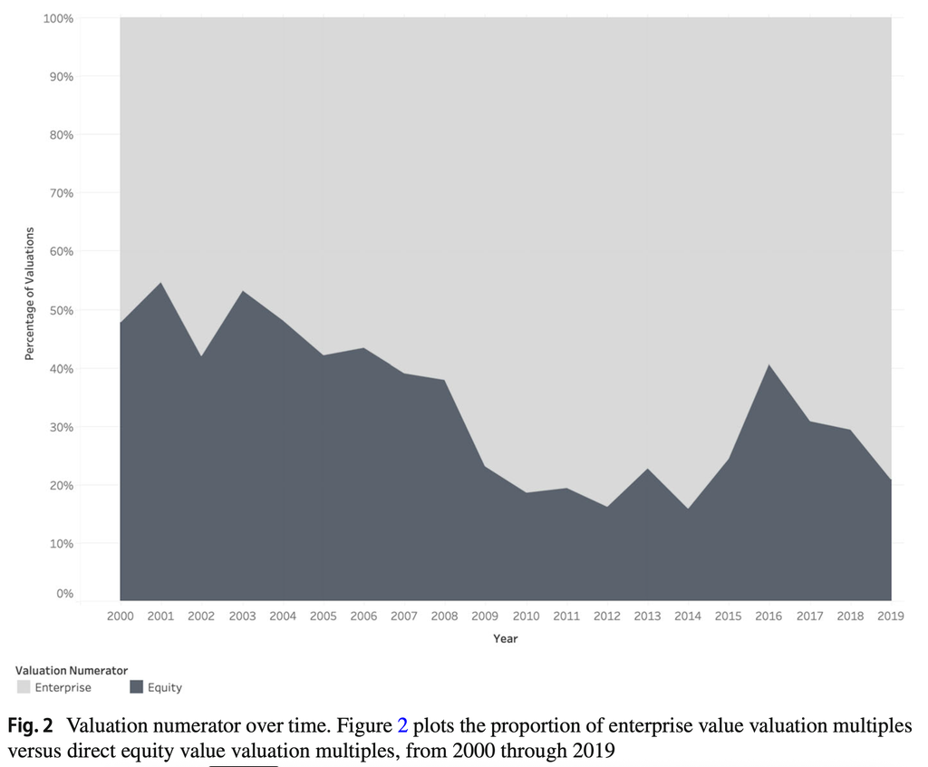

Valuation **numerator** over time (Shaffer 2024)

#### Value-Driver Denominators

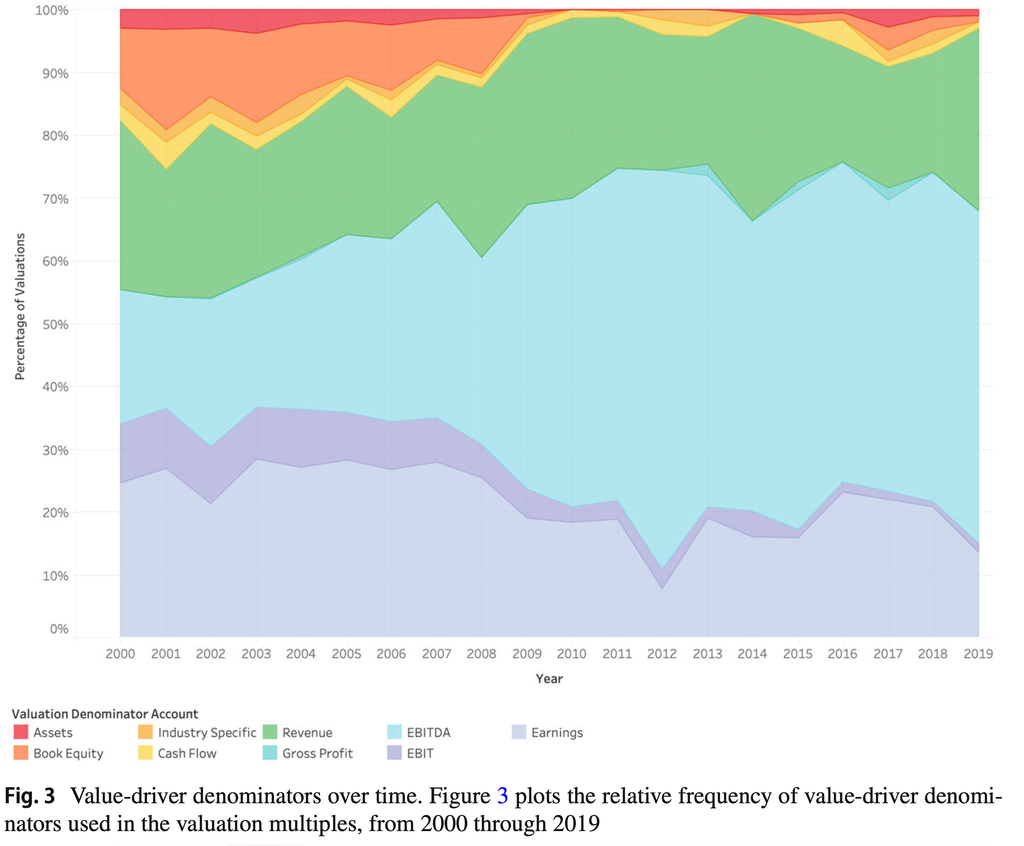

Value-driver **denominators** over time (Shaffer 2024)

## Principles of Market-Based Methods

### Segway through the Valuation Jungle

#### Assumption

Value can be derived from the market value of a **comparable company**

#### Relative Valuation Intuition

$$\begin{equation*}
\text{Multiple} = \frac{\text{What you pay (price)}}{\text{What you get (book)}}
\end{equation*}$$

**$\Rightarrow$ Willingness to pay each EUR of earnings, cash flow, or sales, …**

## Principles of Market-Based Methods

### Segway through the Valuation Jungle

#### Concept

$$MV_T=(MV_{C}/VI_{C})×VI_{T}$$

Where:

- $MV_T$ = Market value of target company
- $MV_C$ = Market value of comparable company C
- $VI_C$ = Value indicator for comparable company C
- $VI_T$ = Value indicator for target company T
- **$(MV_C/VI_C)$ = Market value multiple**

P/E ratio equivalence from earlier: P = PEs of Peers x E

#### Key Points

- Use multiples from comparable companies (peer firms)
- Multiples must be defined identically for all peers
- Select peers: similar profitability, risk, and growth characteristics
- Correlations help identify truly comparable peers (**Fairness Opinions!**)

## Principles of Market-Based Methods Example

### Segway through the Valuation Jungle

*Valuing [Repsol YPF](https://en.wikipedia.org/wiki/Repsol) Using Comparable Integrated Oil Companies*

| Comparable Company | Trailing P/E | Forward P/E | Price/Sales | Price/Book | Average |
| --- | --- | --- | --- | --- | --- |
| Exxon Mobil Corp. (XOM) | 11.25 | 8.73 | 1.17 | 3.71 |  |
| British Petroleum (BP) | 9.18 | 7.68 | 0.69 | 2.17 |  |
| Chevron Corp. (CVX) | 10.79 | 8.05 | 0.91 | 2.54 |  |
| Royal Dutch Shell (RDS-B) | 7.36 | 8.35 | 0.61 | 1.86 |  |
| ConocoPhillips (COP) | 11.92 | 6.89 | 0.77 | 1.59 |  |
| Total SA (TOT) | 8.75 | 8.73 | 0.80 | 2.53 |  |
| Eni SpA (E) | 3.17 | 7.91 | 0.36 | 0.81 |  |
| PetroChina Co. (PTR) | 11.96 | 10.75 | 1.75 | 2.10 |  |
| **Average Multiple** | **9.30** | **8.39** | **0.88** | **2.16** |  |
| $\times$ |  |  |  |  |  |
| Repsol YPF (Projections) | $4.38 | $3.27 | $92.66 | $26.49 |  |
| **= Estimated Market Value** | **$40.72** | **$27.42** | **$81.77** | **$57.32** | **$51.81** |

*Can you calculate a (Trailing) P/E ratio for a company? Try [eBay](https://finance.yahoo.com/quote/EBAY/)!*

## Principles of Market-Based Methods Example

### Segway through the Valuation Jungle

*Valuing [Repsol YPF](https://en.wikipedia.org/wiki/Repsol) Using Comparable Integrated Oil Companies*

- Repsol has economic and political risks and growth characteristics similar to other globally diversified integrated oil and gas companies.
- The estimated value of Repsol based on the comparable companies method is $51.81 billion versus its actual June 25, 2008, market capitalization of $49.83 billion.
- The analyst needs to be mindful of changes in fundamentals that can affect multiples.
  - These fundamentals include a firm’s ability to generate and grow earnings and cash flow through reinvestment in its operations, as well as the risk associated with the firm’s earnings and cash flows.
  - Since multiples are affected by each of these variables, changes in the variables affect them. Firms with lower earnings and cash-flow generation potential, lower growth prospects, and higher risk should trade at multiples less than firms with higher earnings and cash-flow generation capability, higher growth prospects, and less risk.
  - Consequently, the analyst needs to understand why one firm’s multiple is less than a comparable firm’s before concluding that it is under- or overvalued.
  - **For example, a firm with a P/E of 10 may not be more expensive than a comparable firm with a P/E of 8 if the former’s growth prospects, profitability, and rate at which profits are reinvested in the firm are higher than the latter firm’s.**

## Variations of Market-Based Methods

### Segway through the Valuation Jungle

#### Recent Comparable Transactions

- Value of target based on purchase price of recently acquired comparable firms
- Calculate multiples for comparable transactions and apply to target
- Most accurate when transaction is truly comparable and very recent
- Includes a purchase price premium
- Truly comparable recent transactions are rare!

#### Same or Comparable Industry

$$MV_T=(MV_{IND}/VI_{IND})×VI_{T}$$

- Simplifies multiple selection by using industry average multiples
- Assumes industry multiples are comparable
- Requires addition of purchase price premium

## Market-Based Methods

### Segway through the Valuation Jungle

#### Pros of Relative Valuation

- Straight forward to apply
- Transparent assumptions
- Easy to explain
- Conceptual link with discount valuation models

#### Cons of Relative Valuation

- Are comparable firms correctly valued?
- Industry averages may not be good benchmarks (Apple’s peer group includes Nokia and Motorola)
- How to deal with loss making/unlisted firms?
- Adjustment for a purchase price premium (except for recent transactions)
- Accounting distortions (accounting practices such as depreciation/amortization vs. expensing of R&D)

## Segway through the Valuation Jungle

### Valuation and Pricing

#### Selected Valuation Approaches

- Comparable firms, transactions $\checkmark$
- Enterprise value (EV) to EBITDA
- Price / Earnings to Growth ratio (PEG)
- Value-Driver-Based Valuation
- […]

## Enterprise Value to EBITDA

### Segway through the Valuation Jungle

$$EV/EBITDA = (MV_{FCFE} + MV_{PF} + (MV_D - \text{Cash}))/EBITDA$$

Where:

- $MV_{FCFE}$ = Market value of equity
- $MV_{PF}$ = Market value of preferred stock
- $MV_D$ = Market value of debt
- $Cash$ = Cash and cash equivalents
- $EBITDA$ = Earnings before interest, taxes, depreciation, and amortization
- **$EV$ = Enterprise Value**

*$\rightarrow$ construct a multiple for the whole enterprise (equity and debt) rather than just equity*

## Enterprise Value to EBITDA

### Segway through the Valuation Jungle

#### Why useful?

- Capital structure $\rightarrow$ numerator is market value of equity and debt and denominator is operating income
  - Reflects obligation of acquirer to **pay off debt** (what it “costs” to buy the whole business)
  - Allows to compare firms with different levels of debt
  - Net of non-operating asset **cash** whose value is implicitly in equity value
- **EBITDA** less likely to be negative than earnings (no P/E ratio for loss-making firms)
- Limited sensitivity to accounting distortions (“before DA”)

## Enterprise Value to EBITDA

### Segway through the Valuation Jungle

#### Limitations

- Ignores impact of new investments on future cash flows (but firms can grow!)
- Often used for mature firms with stable cash flows and low growth rates

## Enterprise Value to EBITDA Example

### Segway through the Valuation Jungle

> Repsol and Eni are geographically diversified integrated oil and gas companies. The market value of Repsol’s common equity is $40.36 billion, and Eni’s is $54.30 billion. Neither firm has preferred stock outstanding. Repsol’s ($14.6 billion) and Eni’s ($8.8 billion) outstanding debt consists primarily of interest-only notes ($0.7 billion and $0.3 billion, respectively) with a balloon payment at maturity. The average maturity date for Repsol’s debt is 12 years; for Eni’s debt it is 10 years. Market rates of interest for firms like Eni and Repsol at that time for debt maturing within 10 to 12 years were 7% and 7.5%, respectively.

*Calculate EV/EBITDA ratios for Repsol and Eni.*

## Enterprise Value to EBITDA Example

### Segway through the Valuation Jungle

$$EV/EBITDA = (MV_{FCFE} + MV_{PF} + (MV_D - \text{Cash}))/EBITDA$$

Ingredients

- $MV_{FCFE}$ $\rightarrow$ “The market value of Repsol’s common equity is $40.36 billion, and Eni’s is $54.30 billion”
- $MV_{PF}$ $\rightarrow$ “Neither firm has preferred stock outstanding.”
- $MV_D$ $\rightarrow$ ?
- $Cash$ $\rightarrow$ ? [additional info needed]
- $EBITDA$ $\rightarrow$ ? [additional info needed]

## Enterprise Value to EBITDA Example

### Segway through the Valuation Jungle

#### MV (= Present Value) of Repsol’s Long-Term Debt

Use the following formula to calculate the market/present value of the annuity payment

$$\text{MV Annuity} = \text{Payment} \times {\frac {1-(1+i)^{-n}}{i}}$$

then **add** the present value of the balloon payment at maturity

$$\text{MV Balloon} = \frac{\text{Balloon Payment}}{(1+i)^n}$$

to derive at the market value of debt:

$$\text{MV}_D = \$0.7 \times \left[ \frac{1 - 1 / (1.075)^{12}}{0.075} \right] + \frac{\$14.6}{1.075^{12}} = \$0.7 \times 7.74 + \$6.13 = \$11.55 \text{bn}$$

## Enterprise Value to EBITDA Example

### Segway through the Valuation Jungle

#### MV of Eni’s Long-Term Debt

$$\text{MV}_D = \$0.3 \times \left[ \frac{1 - 1 / (1.070)^{10}}{0.07} \right] + \frac{\$8.8}{1.07^{10}}= \$0.3 \times 7.02 + \$4.47 = \$6.58 \text{bn}$$

Book value of debt is often used as a proxy for market value, but this can be misleading for long-term or off-market debt.

## Enterprise Value to EBITDA Example

### Segway through the Valuation Jungle

$$EV/EBITDA = (MV_{FCFE} + 0 + (MV_D - \text{Cash}))/EBITDA$$

| **Balance Sheet** | Repsol | ENI |
| --- | --- | --- |
| *Cash* | 3.8 | 6.2 |
| … |  |  |
| **Income Statement** | Repsol | ENI |
| *Depreciation* | 4.10 | 8.10 |
| *EBIT* | 8.0 | 27.6 |
| *Interest expense* | 0.7 | 0.3 |
| … |  |  |

#### Repsol

$\frac{(\$40.36 + 0 + \$11.55 - \$3.8)}{(\$8.0 + \$4.1)} = 3.98$

#### Eni

$\frac{(\$54.30 + 0 + \$6.58 - \$6.2)}{(\$27.60 + \$8.1)} = 1.53$

## Segway through the Valuation Jungle

### Valuation and Pricing

#### Selected Valuation Approaches

- Comparable firms, transactions $\checkmark$
- Enterprise value (EV) to EBITDA $\checkmark$
- Price / Earnings to Growth ratio (PEG)
- Value-Driver-Based Valuation
- […]

## Adjusting Relative Valuation: PEG Ratio

### Segway through the Valuation Jungle

*Assume that 2 firms are direct competitors and have P/E ratios of 10 and 20, respectively.*

*Which is the cheaper firm?*

$\rightarrow$ Not possible to answer without knowing growth rates of earnings (and what return can be earned from reinvested earnings)!

$\rightarrow$ The **PEG ratio adjusts for differences in growth rates** among comparable firms

## Adjusting Relative Valuation: PEG Ratio

### Segway through the Valuation Jungle

$\rightarrow$ The **PEG ratio (A) adjusts for differences in growth rates** among comparable firms:

$$A = \frac{MV_C/VI_C}{VI_{CGR}}$$

Where:

- $MV_C/VI_C$ = Market price to value indicator multiple (P/E) for comparable firms
- $VI_{CGR}$ = Projected growth rate in value indicator for comparable firms

$\Rightarrow$ **A is the PEG ratio for comparable firms**

## Adjusting Relative Valuation: PEG Ratio

### Segway through the Valuation Jungle

When applying this adjustment, the Market Value Multiple Valuation
$$MV_T=(MV_{C}/VI_{C})×VI_{T}$$

becomes

$$\boxed{MV_T = A \times VI_{TGR} \times VI_T}$$

where

- $A$ = **PEG ratio for comparable firms**, which is the market price to value indicator relative to growth rate for comparable firms
- $VI_T$ = Value indicator for target
- $VI_{TGR}$ = Projected growth rate in value indicator of target firm

## Adjusting Relative Valuation: PEG Ratio Example

### Segway through the Valuation Jungle

> An analyst is asked to determine whether Basic Energy Service (BES) or Composite Production Services (CPS) is more attractive as an acquisition target. Both firms provide engineering, construction, and specialty services to the oil, gas, refinery, and petrochemical industries. BES and CPS have *projected annual earnings per share growth rates of 15% and 9%*, respectively. BES’s and CPS’s *current earnings per share are $2.05 and $3.15*, respectively. The current *share prices for BES are $31.48 and for CPX are $26.00. The industry average [assume that industry peers are comparable firms here] price-to-earnings ratio and growth rate are 12.4% and 11%*, respectively.

*Calculate valuations using the PEG ratio (for comparable firms) and discuss which firm is a more attractive takeover target as of now.*

## Adjusting Relative Valuation: PEG Ratio Example

### Segway through the Valuation Jungle

#### Calculate Valuations Using PEG Ratio

- Industry average PEG ratio: $A = \frac{MV_C/VI_C}{VI_{CGR}} = \frac{12.4}{11} = 1.13$
- BES implied share price: $MV_T = A \times VI_{TGR} \times VI_T = 1.13 \times 15 \times 2.05 = 34.66$
- CPS implied share price: $MV_T = A \times VI_{TGR} \times VI_T = 1.13 \times 9 \times 3.15 = 31.96$
- Important: Consistent percentage point vs. decimals in growth rates!

## Adjusting Relative Valuation: PEG Ratio Example

### Segway through the Valuation Jungle

#### Takeover Target Attractiveness

| Firm | Implied Price | Current Price | Upside (%) |
| --- | --- | --- | --- |
| BES | $34.66 | $31.48 | +10.1% |
| CPS | $31.96 | $26.00 | +23.0% |

- CPS appears to be a more attractive acquisition target than BES based on the PEG ratio, as it has a higher upside potential of 23% compared to BES’s 10.1% (although BES has both a higher growth rate and a higher implied share price).
- BES might be a more attractive acquisition target if it generates increasing future financial returns (and if its projected earnings stream is viewed as less risky).

## Adjusting Relative Valuation: PEG Ratio

### Segway through the Valuation Jungle

#### Firm PEG Ratio

*One can move from a PEG ratio for comparable firms to a PEG ratio for the target firm by using (i) the target firm’s market price to value indicator in the numerator ($MV_T/VI_T$,e.g., P/E) and (ii) the target firm’s projected growth rate ($VI_{TGR}$) in the denominator:*

$$A_T = \frac{MV_T/VI_T}{VI_{TGR}}$$

#### Interpretation

- $A_T$ > $A$ $\rightarrow$ target priced more expensively than peers (conditional on growth)
- $A_T$ < $A$ $\rightarrow$ target priced more cheaply than peers (conditional on growth)

## Segway through the Valuation Jungle

### Valuation and Pricing

#### Selected Valuation Approaches

- Comparable firms, transactions $\checkmark$
- Enterprise value (EV) to EBITDA $\checkmark$
- Price / Earnings to Growth ratio (PEG) $\checkmark$
- Value-Driver-Based Valuation
- […]

## Value-Driver-Based Valuation

### Segway through the Valuation Jungle

*What to do when earnings are missing?*

#### Micro Value Drivers

- Influence **specific functions** within the firm, e.g., sales, marketing, production, and distribution (e.g., Part Defects per X Units Sold)

#### Macro value drivers

- Influence all aspects of the firm (e.g., *market share* or overall customer satisfaction)

## Value-Driver-Based Valuation

### Segway through the Valuation Jungle

#### Appliying Value-Driver-Based Valuation

1. Identify value drivers of the firm
2. Market value for comparable companies divided by value driver = $ of market value per unit of value driver
3. Multiply with same value driver for target firm = $MV_T$

$\Rightarrow$ implied assumption that a single value driver is representative of the total value of the business (Dot-com bubble)

## Segway through the Valuation Jungle

### Valuation and Pricing

#### Selected Valuation Approaches

- Comparable firms, transactions $\checkmark$
- Enterprise value (EV) to EBITDA $\checkmark$
- Price / Earnings to Growth ratio (PEG) $\checkmark$
- Value-Driver-Based Valuation $\checkmark$
- […] $\rightarrow$ DePamphilis (2025)

## When to use which method?

[output not shown]

# Apples and Peers: Empirical Evidence

## Comparable Companies

### Peer Selection and Valuation in M&A (Eaton et al. 2022)

#### Research Question

What drives investment IBs’ choice of peers in comparable companies analysis?

#### Results

- Product market space is among the most important factors in peer selection
  - but: SIC codes do a poor job of categorizing related firms
- Banks strategically select large, high growth peers with high valuation multiples:
  - helps target to negotiate higher takeover price
  - against banks’ incentives to collect success fees (lower valuations could increase deal closing probability)

## UBS’s opinion: Schneider Electric SA buys BEI Technologies

### Peer Selection and Valuation in M&A (Eaton et al. 2022)

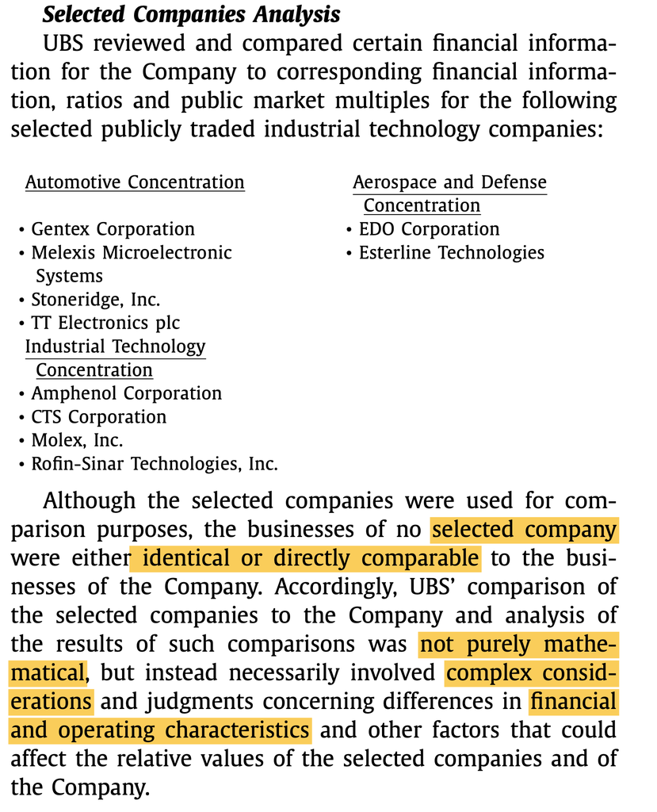

## Takeaways

#### Fairness Opinions

- Board’s Fiduciary Responsibilities (duties of care and loyalty) in transactions require professional/external evaluation of transaction fairness
- FOs historically evolved following the Trans Union case
  - Can be strategic tools influenced by litigation risk and agency conflicts
  - Fee structures create potential conflicts of interest

#### Measuring Value

- Market-based methods are derived from fundamental discount principles
- Multiples (comparables, transactions, asset-based) serve different contexts
- Method selection depends on company characteristics and available information
- Each method has strengths and limitations

## Thank You!

[figure not shown]

## References

DePamphilis, Donald M. 2025. *Mergers, Acquisitions, and Other Restructuring Activities*. Academic Press.

Eaton, Gregory W, Feng Guo, Tingting Liu, and Micah S Officer. 2022. “Peer Selection and Valuation in Mergers and Acquisitions.” *Journal of Financial Economics* 146 (1): 230–55.

Shaffer, Matthew. 2024. “Which multiples matter in M&A.” *Review of Accounting Studies* 29 (3): 2724–52.

## Copyright

### © Erasmus University Rotterdam, all rights reserved. No text and data mining.

Titlepage photo by [Dennis Möller](https://unsplash.com/@ennismo?utm_source=unsplash&utm_medium=referral&utm_content=creditCopyText) on [Unsplash](https://unsplash.com/photos/city-skyline-under-blue-sky-during-night-time-946XeVrYO2E?utm_source=unsplash&utm_medium=referral&utm_content=creditCopyText)